# Predictive Modeling of Movie Gross Revenue

Student Name

2025-08-20

This report details the process of building a predictive model for movie gross revenue using the Conventional and Social Media Movies (CSM) dataset. The analysis covers comprehensive data preprocessing, robust model selection and validation, assumption checking, and a comparison with an alternative machine learning approach.

### Library and Data Initialization

First, we load all necessary R libraries and the dataset. For this document to be self-contained and reproducible, the dataset file (`CSM.xlsx`) should be located in the same directory as this R Markdown file.

```r
# Import libraries for the entire analysis
library(ggplot2)
library(corrplot)
library(car)
library(naniar)
library(VIM)
library(MASS)
library(lmtest)
library(dplyr)
library(leaps)
library(skimr)
library(GGally)
library(missForest)
library(caret)
library(xgboost)
library(effects)
library(openxlsx)

# Load the dataset from the CSV file.
# The original script used read.xlsx; we use read.csv for the provided file format.
data_raw <- read.xlsx("CSM.xlsx")

# Remove the final empty row that exists in the CSV file
data_raw <- data_raw[rowSums(is.na(data_raw)) != ncol(data_raw), ]

# Display the dimensions and a preview of the data
cat("Dataset dimensions:", dim(data_raw), "\n")
```

```
## Dataset dimensions: 231 14
```

```r
head(data_raw)
```

```
##                                   Movie Year Ratings Genre    Gross   Budget
## 1                        Jurassic World 2015     7.3     1 6.43e+08 1.50e+08
## 2               Avengers: Age of Ultron 2015     7.8     1 4.58e+08 2.50e+08
## 3                       American Sniper 2014     7.3     1 3.50e+08 5.88e+07
## 4                             Furious 7 2015     7.4     1 3.50e+08 1.90e+08
## 5                            Inside Out 2015     8.6    12 3.45e+08 1.75e+08
## 6 The Hunger Games: Mockingjay - Part 1 2014     6.8     2 3.37e+08 1.25e+08
##   Screens Sequel Sentiment    Views Likes Dislikes Comments Aggregate.Followers
## 1    4274      4         1  9143740 34746     1074     5107             6180000
## 2    4276      2        21 10366624 31552      989     3843            10070000
## 3    3555      1         4  3927600 13143      573     3134               24300
## 4    4004      7       -17    59056   330        8       39            11890000
## 5    3946      1         2  1438926  4632      262      496              232000
## 6    4151      3         2  3305417 14684      332     1176            31030000
```

## a) Preprocess the data

Preprocessing is a critical first step to ensure data quality and prepare the dataset for modeling. This involves understanding the data structure, handling missing values, and performing initial exploratory data analysis.

### Data Structure and Summary

We start by examining the structure and statistical summaries of each variable.

```r
# str() provides a compact view of the data frame's structure and variable types.
str(data_raw)
```

```
## 'data.frame':    231 obs. of  14 variables:
##  $ Movie              : chr  "Jurassic World" "Avengers: Age of Ultron" "American Sniper" "Furious 7" ...
##  $ Year               : num  2015 2015 2014 2015 2015 ...
##  $ Ratings            : num  7.3 7.8 7.3 7.4 8.6 6.8 8.1 6.6 7.8 7.8 ...
##  $ Genre              : num  1 1 1 1 12 2 1 1 1 12 ...
##  $ Gross              : num  6.43e+08 4.58e+08 3.50e+08 3.50e+08 3.45e+08 3.37e+08 3.33e+08 3.25e+08 2.60e+08 2.58e+08 ...
##  $ Budget             : num  1.50e+08 2.50e+08 5.88e+07 1.90e+08 1.75e+08 1.25e+08 1.70e+08 7.40e+07 1.70e+08 6.00e+07 ...
##  $ Screens            : num  4274 4276 3555 4004 3946 ...
##  $ Sequel             : num  4 2 1 7 1 3 1 2 2 1 ...
##  $ Sentiment          : num  1 21 4 -17 2 2 0 -2 5 -2 ...
##  $ Views              : num  9143740 10366624 3927600 59056 1438926 ...
##  $ Likes              : num  34746 31552 13143 330 4632 ...
##  $ Dislikes           : num  1074 989 573 8 262 ...
##  $ Comments           : num  5107 3843 3134 39 496 ...
##  $ Aggregate.Followers: num  6180000 10070000 24300 11890000 232000 ...
```

```r
# The skim() function provides a more detailed summary, including missing values,
# quantiles, and a small histogram for numeric variables.
skim(data_raw)
```

Data summary

| Name | data_raw |
| --- | --- |
| Number of rows | 231 |
| Number of columns | 14 |
| _______________________ |  |
| Column type frequency: |  |
| character | 1 |
| numeric | 13 |
| ________________________ |  |
| Group variables | None |

**Variable type: character**

| skim_variable | n_missing | complete_rate | min | max | empty | n_unique | whitespace |
| --- | --- | --- | --- | --- | --- | --- | --- |
| Movie | 0 | 1 | 3 | 41 | 0 | 231 | 0 |

**Variable type: numeric**

| skim_variable | n_missing | complete_rate | mean | sd | p0 | p25 | p50 | p75 | p100 | hist |
| --- | --- | --- | --- | --- | --- | --- | --- | --- | --- | --- |
| Year | 0 | 1.00 | 2014.29 | 0.46 | 2014.0 | 2014.0 | 2014.0 | 2015.0 | 2015.0 | ▇▁▁▁▃ |
| Ratings | 0 | 1.00 | 6.44 | 0.99 | 3.1 | 5.8 | 6.5 | 7.1 | 8.7 | ▁▂▇▇▂ |
| Genre | 0 | 1.00 | 5.36 | 4.14 | 1.0 | 1.0 | 3.0 | 8.0 | 15.0 | ▇▁▅▂▁ |
| Gross | 0 | 1.00 | 68066033.20 | 88902891.22 | 2470.0 | 10300000.0 | 37400000.0 | 89350000.0 | 643000000.0 | ▇▁▁▁▁ |
| Budget | 1 | 1.00 | 47921730.05 | 54288246.07 | 70000.0 | 9000000.0 | 28000000.0 | 65000000.0 | 250000000.0 | ▇▂▁▁▁ |
| Screens | 10 | 0.96 | 2209.24 | 1463.77 | 2.0 | 449.0 | 2777.0 | 3372.0 | 4324.0 | ▇▁▂▇▅ |
| Sequel | 0 | 1.00 | 1.36 | 0.97 | 1.0 | 1.0 | 1.0 | 1.0 | 7.0 | ▇▁▁▁▁ |
| Sentiment | 0 | 1.00 | 2.81 | 7.00 | -38.0 | 0.0 | 0.0 | 5.5 | 29.0 | ▁▁▇▃▁ |
| Views | 0 | 1.00 | 3712851.29 | 4511104.24 | 698.0 | 623302.0 | 2409338.0 | 5217379.5 | 32626778.0 | ▇▂▁▁▁ |
| Likes | 0 | 1.00 | 12732.54 | 28825.48 | 1.0 | 1776.5 | 6096.0 | 15247.5 | 370552.0 | ▇▁▁▁▁ |
| Dislikes | 0 | 1.00 | 679.05 | 1243.93 | 0.0 | 105.5 | 341.0 | 697.5 | 13960.0 | ▇▁▁▁▁ |
| Comments | 0 | 1.00 | 1825.70 | 3571.04 | 0.0 | 248.5 | 837.0 | 2137.0 | 38363.0 | ▇▁▁▁▁ |
| Aggregate.Followers | 35 | 0.85 | 3038193.45 | 4886278.07 | 1066.0 | 183025.0 | 1052600.0 | 3694500.0 | 31030000.0 | ▇▁▁▁▁ |

**Interpretation:** The summaries reveal that the dataset contains numerical and character (`Movie`) variables. Several variables, notably `Screens` and `Aggregate.Followers`, contain missing values (`n_missing > 0`). Many of the numerical predictors like `Gross`, `Budget`, `Views`, and `Likes` are highly right-skewed, which is evident from the mean being much larger than the median and the shape of the inline histograms. This skewness will likely violate the assumptions of linear regression and may require transformation.

### Missing Data Analysis

A thorough analysis of missing data is required to choose an appropriate handling strategy. We first visualize the extent and pattern of missingness.

```r
# Create a summary table of missing values per variable.
miss_var_summary(data_raw)
```

```
## # A tibble: 14 × 3
##    variable            n_miss pct_miss
##    <chr>                <int>    <num>
##  1 Aggregate.Followers     35   15.2
##  2 Screens                 10    4.33
##  3 Budget                   1    0.433
##  4 Movie                    0    0
##  5 Year                     0    0
##  6 Ratings                  0    0
##  7 Genre                    0    0
##  8 Gross                    0    0
##  9 Sequel                   0    0
## 10 Sentiment                0    0
## 11 Views                    0    0
## 12 Likes                    0    0
## 13 Dislikes                 0    0
## 14 Comments                 0    0
```

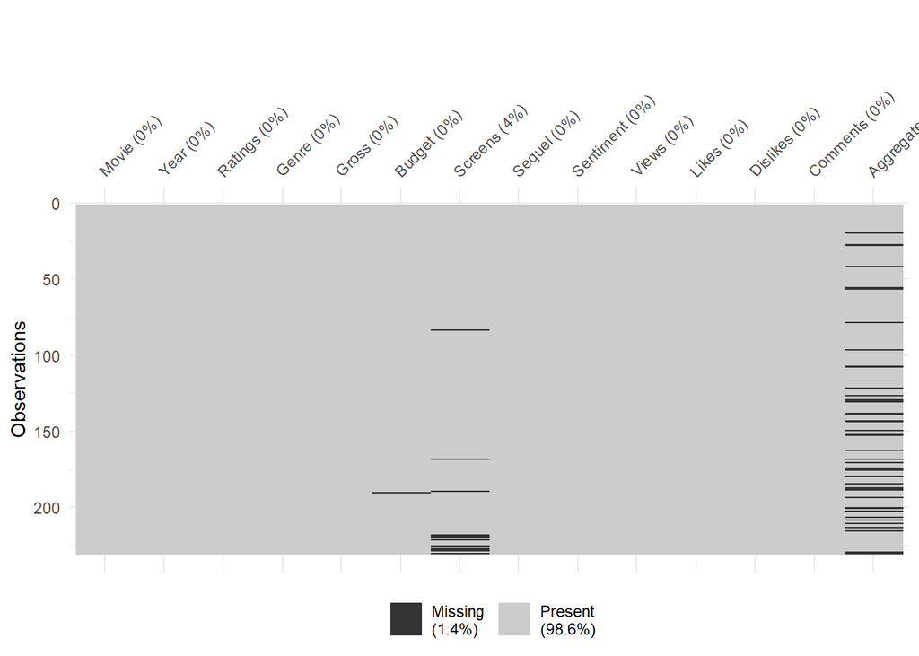

```r
# The vis_miss plot provides a heatmap-like overview of missing data locations.
vis_miss(data_raw, warn_large_data = FALSE)
```

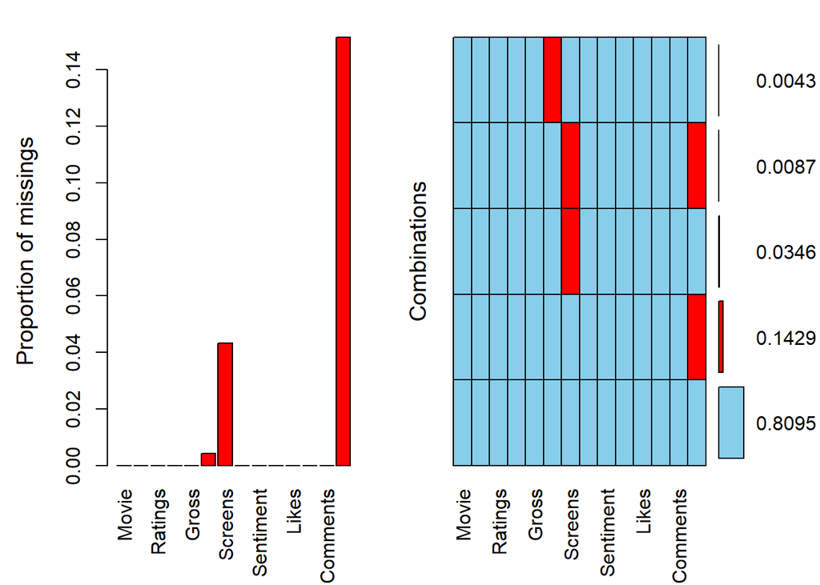

```r
# The aggr plot from the VIM package shows the amount of missingness
# for each variable and for combinations of variables.
aggr(data_raw, prop = TRUE, numbers = TRUE)
```

**Interpretation:** `Aggregate.Followers` has the highest percentage of missing data at 15.2%, followed by `Screens` at 4.3%, and `Budget` at 0.433%. The `aggr` plot shows that most missingness occurs in `Aggregate.Followers` alone. To select the correct imputation method, we need to understand the missing data mechanism.

### Investigating the Missing Data Mechanism

We test whether the data is Missing Completely at Random (MCAR) or if the probability of a value being missing is related to other observed variables (Missing at Random - MAR).

First, we use logistic regression to predict the missingness of `Aggregate.Followers` based on other variables. If other variables can predict missingness, this is evidence for MAR.

Suppose the missingness of `Aggregate.Followers` is based on `Views`, `Likes`, `Budget`, `Screens`, and `Ratings`.

```r
# Create an indicator variable: 1 if Aggregate.Followers is missing, 0 otherwise.
data_mar_test <- data_raw %>%
  mutate(missing_followers = ifelse(is.na(Aggregate.Followers), 1, 0))

# Fit a logistic regression model.
logit_model <- glm(
  missing_followers ~ Views + Likes + Budget + Screens + Ratings,
  data = data_mar_test,
  family = binomial(link = "logit")
)
summary(logit_model)
```

```
##
## Call:
## glm(formula = missing_followers ~ Views + Likes + Budget + Screens +
##     Ratings, family = binomial(link = "logit"), data = data_mar_test)
##
## Coefficients:
##               Estimate Std. Error z value Pr(>|z|)
## (Intercept) -4.713e+00  1.617e+00  -2.915  0.00356 **
## Views        8.750e-08  1.082e-07   0.808  0.41885
## Likes       -3.422e-05  3.900e-05  -0.877  0.38031
## Budget      -1.568e-08  7.271e-09  -2.157  0.03104 *
## Screens     -8.423e-05  1.764e-04  -0.477  0.63309
## Ratings      5.742e-01  2.373e-01   2.420  0.01553 *
## ---
## Signif. codes:  0 '***' 0.001 '**' 0.01 '*' 0.05 '.' 0.1 ' ' 1
##
## (Dispersion parameter for binomial family taken to be 1)
##
##     Null deviance: 185.99  on 219  degrees of freedom
## Residual deviance: 167.68  on 214  degrees of freedom
##   (11 observations deleted due to missingness)
## AIC: 179.68
##
## Number of Fisher Scoring iterations: 6
```

**Interpretation:** The logistic regression model was fit to determine if the probability of `Aggregate.Followers` being missing is systematically related to other observed variables in the dataset. The results provide key insights into the missing data mechanism:

- **Significant Predictors**: Two variables were found to be statistically significant predictors of missingness: `Budget` (p = 0.031) and `Ratings` (p = 0.016).
- **Effect of Budget**: The coefficient for `Budget` is negative (-1.568e-08). This indicates that for every unit increase in a movie’s budget, the log-odds of its follower data being missing decrease. In practical terms, movies with lower budgets are significantly more likely to have missing `Aggregate.Followers` data.
- **Effect of Ratings**: The coefficient for `Ratings` is positive (0.574). This implies that movies with higher ratings are also more likely to have their follower data missing. This might seem counter-intuitive but could reflect a pattern where niche or art-house films receive high critical ratings but lack the broad social media presence that is typically tracked.

Since the likelihood of a value being missing in `Aggregate.Followers` is clearly dependent on at least two other observed variables, we have strong evidence to reject the assumption that the data is Missing Completely at Random (MCAR).

=> This result strongly supports the Missing at Random (MAR) assumption, which means that a sophisticated imputation method that can model these relationships is appropriate.

We can further support this with t-tests, comparing the means of key variables for observations with and without missing followers.

```r
# T-test for Budget
t.test(Budget ~ missing_followers, data = data_mar_test)
```

```
##
##  Welch Two Sample t-test
##
## data:  Budget by missing_followers
## t = 4.3501, df = 89.681, p-value = 3.591e-05
## alternative hypothesis: true difference in means between group 0 and group 1 is not equal to 0
## 95 percent confidence interval:
##  15015925 40262286
## sample estimates:
## mean in group 0 mean in group 1
##        52127681        24488575
```

```r
# T-test for Likes
t.test(Likes ~ missing_followers, data = data_mar_test)
```

```
##
##  Welch Two Sample t-test
##
## data:  Likes by missing_followers
## t = 1.9168, df = 166.46, p-value = 0.05698
## alternative hypothesis: true difference in means between group 0 and group 1 is not equal to 0
## 95 percent confidence interval:
##   -159.8292 10810.0598
## sample estimates:
## mean in group 0 mean in group 1
##       13539.372        8214.257
```

**Interpretation:** The t-test for `Budget` shows a highly significant difference in means (p < 0.001), confirming that movies with missing follower data have a much lower average budget. The test for `Likes` is marginally significant (p=0.057), suggesting a similar trend. This collective evidence strongly points to a MAR mechanism.

Finally, we perform Little’s MCAR test, where the null hypothesis is that data is MCAR.

```r
# Refined subset for MCAR
numeric_data <- data_raw %>%
  select(where(is.numeric)) %>%
  select(-Genre, -Sequel, -Sentiment, -Year)

near_zero_var <- nearZeroVar(numeric_data)
if (length(near_zero_var) > 0) numeric_data <- numeric_data[, -near_zero_var]

numeric_data_scaled <- scale(numeric_data)

mcar_test_result <- mcar_test(as.data.frame(numeric_data_scaled))
print(mcar_test_result)
```

```
## # A tibble: 1 × 4
##   statistic    df p.value missing.patterns
##       <dbl> <dbl>   <dbl>            <int>
## 1      45.2    31  0.0482                5
```

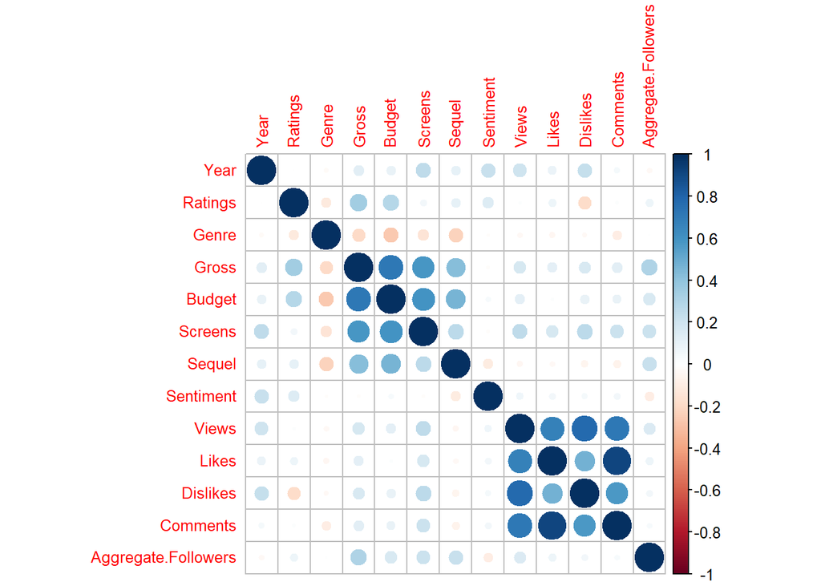

```r
# Missing correlations
num_vars_with_miss <- data_raw %>%
  select(where(is.numeric))
cor_matrix_miss <- cor(num_vars_with_miss, use = "pairwise.complete.obs")
corrplot(cor_matrix_miss, method = "circle", tl.cex = 0.8)
```

**Interpretation:** The p-value (0.048) from Little’s test is less than 0.05, leading us to reject the null hypothesis. This formally confirms that the data is **not** Missing Completely at Random.

### Data Imputation

Given the strong evidence for MAR, we can use a sophisticated imputation method that leverages relationships between variables. We choose `missForest`, which uses a random forest algorithm to predict and fill in missing values. It can handle mixed data types and complex interactions effectively.

```r
df <- data_raw[rowSums(is.na(data_raw)) != ncol(data_raw), ]

df_impute <- df[, -which(names(df) == "Movie")]

cols_to_factor <- c("Genre", "Year")
df_impute[cols_to_factor] <- lapply(df_impute[cols_to_factor], factor)

set.seed(123)
result_imputation <- missForest(df_impute, verbose = TRUE, ntree = 100)
```

```
##   missForest iteration 1 in progress...done!
##     estimated error(s): 0.2450955 0
##     difference(s): 0.0004215305 0
##     time: 0.12 seconds
##
##   missForest iteration 2 in progress...done!
##     estimated error(s): 0.2484268 0
##     difference(s): 1.932914e-06 0
##     time: 0.14 seconds
##
##   missForest iteration 3 in progress...done!
##     estimated error(s): 0.2456973 0
##     difference(s): 2.44642e-06 0
##     time: 0.13 seconds
```

```r
df_completed <- result_imputation$ximp
df_completed$Aggregate.Followers <- round(df_completed$Aggregate.Followers)

sapply(df_completed, function(x) sum(is.na(x)))
```

```
##                Year             Ratings               Genre               Gross
##                   0                   0                   0                   0
##              Budget             Screens              Sequel           Sentiment
##                   0                   0                   0                   0
##               Views               Likes            Dislikes            Comments
##                   0                   0                   0                   0
## Aggregate.Followers
##                   0
```

```r
print(result_imputation$OOBerror)
```

```
##     NRMSE       PFC
## 0.2484268 0.0000000
```

```r
neg_checks <- sapply(c("Budget", "Gross", "Aggregate.Followers"), function(col) sum(df_completed[[col]] < 0))
print(neg_checks)
```

```
##              Budget               Gross Aggregate.Followers
##                   0                   0                   0
```

**Interpretation:** The imputation process has completed, and the dataset now has no missing values. The low OOB error suggests that the imputations are of good quality. We can now proceed with the imputed dataset.

### Post-Imputation Exploratory Data Analysis (EDA)

Before modeling, we perform a final EDA on the complete data to understand relationships and confirm data characteristics.

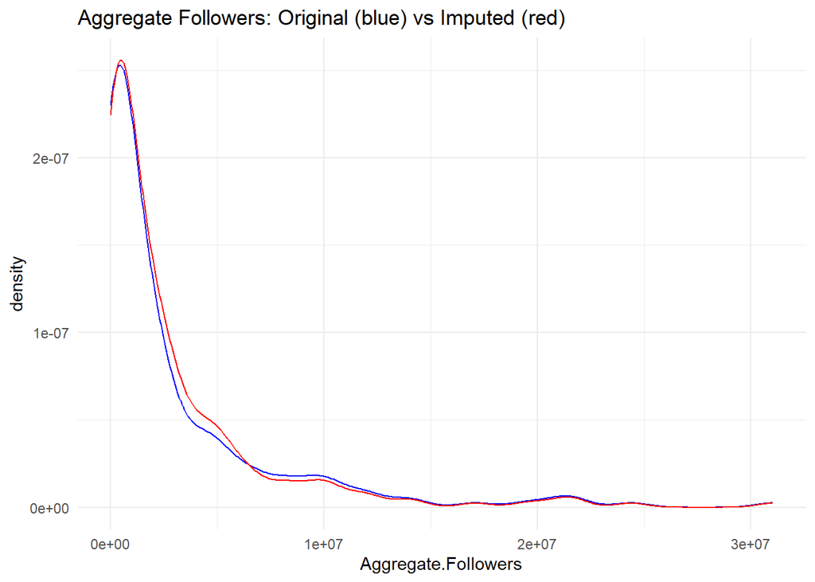

```r
complete_data <- df_completed

ggplot() +
  geom_density(data = data_raw, aes(x = Aggregate.Followers), color = "blue", na.rm = TRUE) +
  geom_density(data = complete_data, aes(x = Aggregate.Followers), color = "red") +
  labs(title = "Aggregate Followers: Original (blue) vs Imputed (red)") +
  theme_minimal()
```

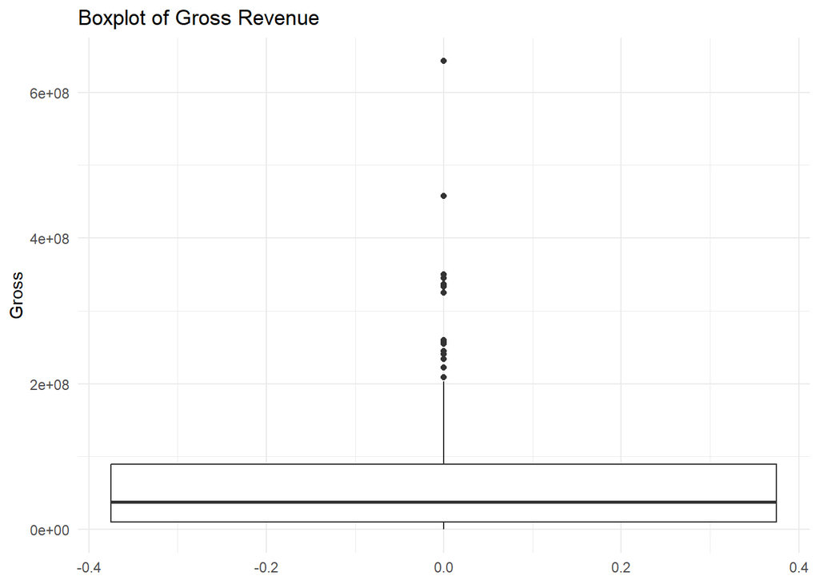

```r
ggplot(complete_data, aes(y = Gross)) +
  geom_boxplot() +
  theme_minimal() +
  ggtitle("Boxplot of Gross Revenue")
```

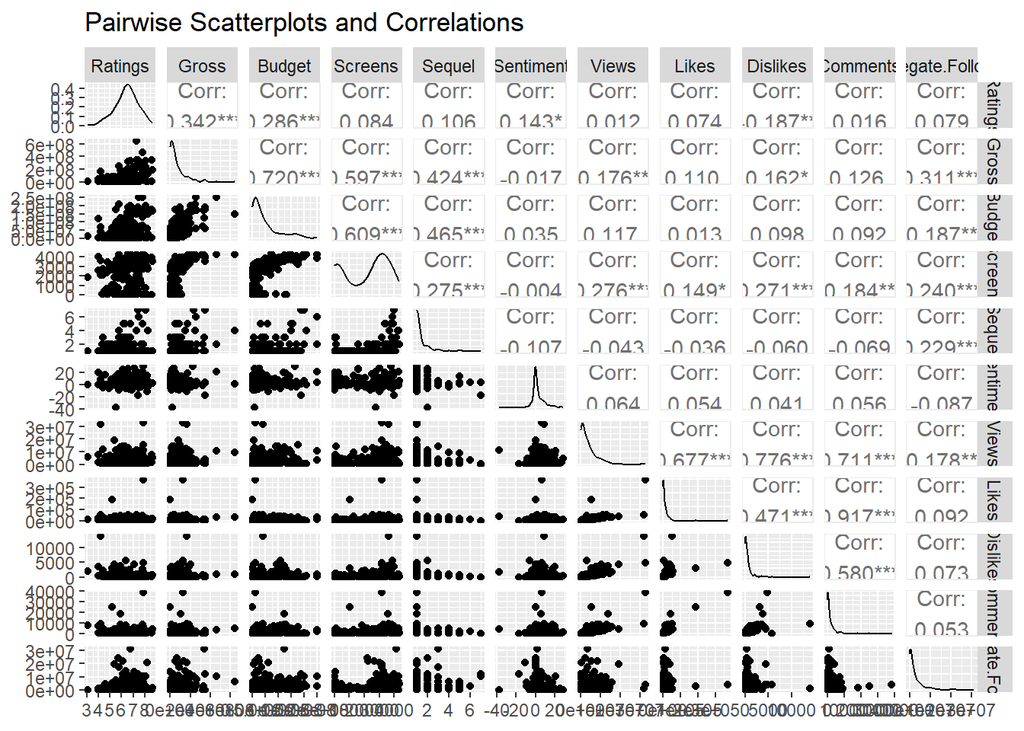

```r
library(GGally)
num_vars <- dplyr::select(complete_data, where(is.numeric))
ggpairs(num_vars, title = "Pairwise Scatterplots and Correlations")
```

**Interpretation:** The density plot shows that the imputation has preserved the overall distribution of `Aggregate.Followers`, which is a good sign. The boxplot for `Gross` confirms the severe right-skewness and presence of high-end outliers, reinforcing the need for transformation during the modeling phase.

## b) Split the dataset

We partition the complete dataset into a training set (80%) for model building and a validation set (20%) for evaluating the final model’s performance on unseen data.

```r
# Set a seed to ensure the split is reproducible.

set.seed(50)

# Create an index for the training set.
train_index <- sample(1:nrow(complete_data), size = 0.8 * nrow(complete_data))

# Create the training and validation sets.
train <- complete_data[train_index, ]
valid <- complete_data[-train_index, ]

# Print the dimensions of the resulting sets.
cat("Training set rows:", nrow(train), "\n")
```

```
## Training set rows: 184
```

```r
cat("Validation set rows:", nrow(valid), "\n")
```

```
## Validation set rows: 47
```

## c) Model selection

This section details the iterative process of selecting the best linear regression model to explain `Gross`. The process includes feature selection, assumption diagnostics, outlier handling, and variable transformations.

### Initial Full Model

We begin by fitting a model that includes all potential predictors to serve as a starting point.

```r
full_model <- lm(Gross ~ ., data = train)
summary(full_model)
```

```
##
## Call:
## lm(formula = Gross ~ ., data = train)
##
## Residuals:
##        Min         1Q     Median         3Q        Max
## -112259452  -30324174   -4394688   19041975  416247723
##
## Coefficients:
##                       Estimate Std. Error t value Pr(>|t|)
## (Intercept)         -1.310e+08  3.657e+07  -3.582 0.000450 ***
## Year2015            -1.322e+07  1.132e+07  -1.168 0.244569
## Ratings              1.907e+07  5.308e+06   3.592 0.000435 ***
## Genre2              -3.099e+07  2.129e+07  -1.455 0.147556
## Genre3              -1.662e+07  1.393e+07  -1.193 0.234611
## Genre4              -3.419e+07  5.956e+07  -0.574 0.566714
## Genre6              -3.338e+07  3.496e+07  -0.955 0.341097
## Genre7               1.835e+07  4.322e+07   0.425 0.671699
## Genre8              -1.439e+07  1.447e+07  -0.994 0.321479
## Genre9              -1.478e+07  2.077e+07  -0.711 0.477802
## Genre10             -3.188e+07  2.125e+07  -1.500 0.135519
## Genre12             -1.001e+07  2.126e+07  -0.471 0.638530
## Genre15              1.258e+07  2.432e+07   0.517 0.605760
## Budget               6.944e-01  1.245e-01   5.577    1e-07 ***
## Screens              1.396e+04  4.090e+03   3.413 0.000812 ***
## Sequel               1.360e+07  5.454e+06   2.494 0.013638 *
## Sentiment           -4.649e+03  6.332e+05  -0.007 0.994151
## Views               -1.855e+00  1.803e+00  -1.029 0.304892
## Likes                6.158e+02  6.468e+02   0.952 0.342457
## Dislikes             1.304e+04  5.774e+03   2.258 0.025296 *
## Comments            -4.026e+03  4.699e+03  -0.857 0.392848
## Aggregate.Followers  2.535e+00  1.020e+00   2.486 0.013941 *
## ---
## Signif. codes:  0 '***' 0.001 '**' 0.01 '*' 0.05 '.' 0.1 ' ' 1
##
## Residual standard error: 57220000 on 162 degrees of freedom
## Multiple R-squared:  0.6513, Adjusted R-squared:  0.6061
## F-statistic: 14.41 on 21 and 162 DF,  p-value: < 2.2e-16
```

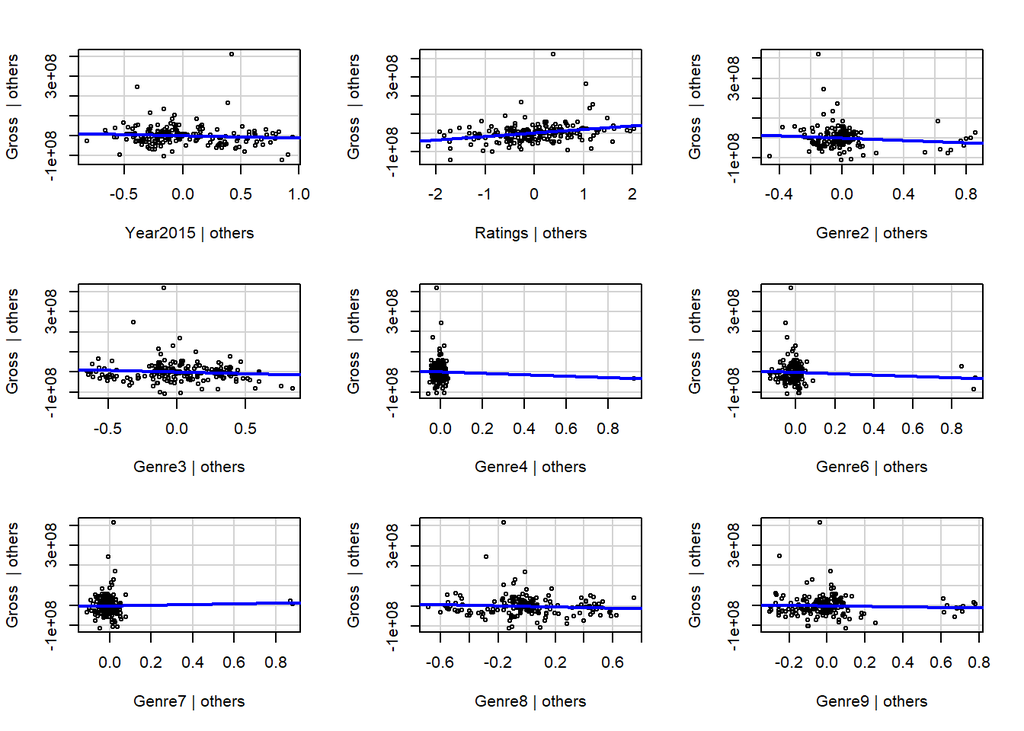

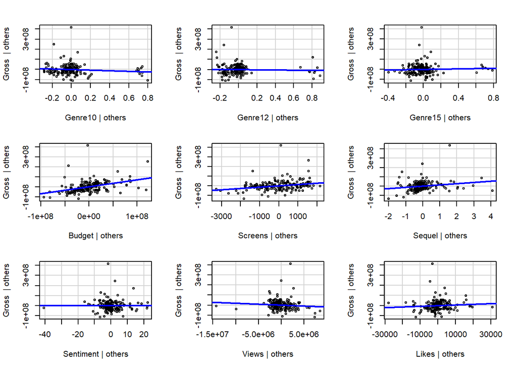

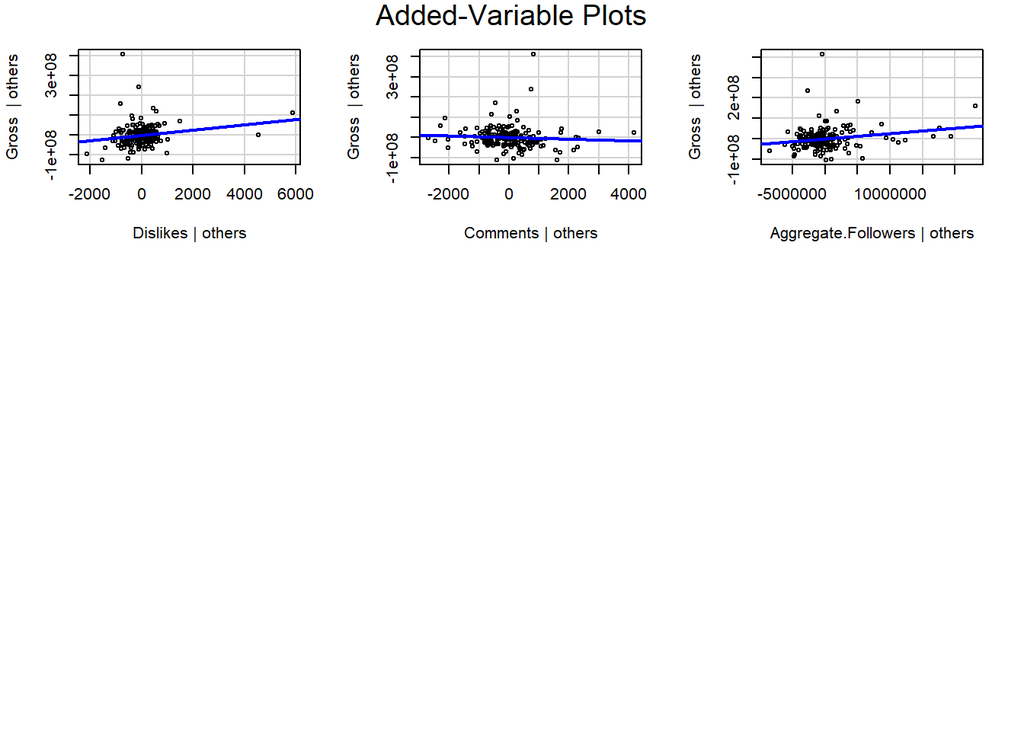

```r
avPlots(full_model, id = FALSE)
```

**Interpretation:**

**Conclusion**: The model is too complex. Many variables (e.g., Year, most Genre types, Sentiment) are not significant, which justifies using feature selection to create a simpler, more effective model.

### Feature Selection

The initial full_model, while having a high R-squared, was overly complex and contained many statistically insignificant variables. The goal of this stage is to simplify the model by retaining only the most important predictors, creating a model that is both powerful in its explanatory ability and parsimonious for better interpretation. We will use a combination of two methods: stepwise selection and best subset selection.

#### Backward Stepwise Selection

This method begins with the full model and systematically removes the least significant variable at each step until no further improvement can be made according to a specific criterion. We will use two common criteria, AIC and BIC.

- **AIC (Akaike Information Criterion)**: Balances model fit and complexity.
- **BIC (Bayesian Information Criterion)**: Similar to AIC but imposes a stronger penalty for model complexity, thus tending to select smaller models.

```r
# Backward selection using AIC (Akaike Information Criterion)
step_aic <- step(full_model, direction = "backward", trace = 0)
cat("--- Model selected by AIC --- \n")
```

```
## --- Model selected by AIC ---
```

```r
summary(step_aic)
```

```
##
## Call:
## lm(formula = Gross ~ Ratings + Budget + Screens + Sequel + Dislikes +
##     Aggregate.Followers, data = train)
##
## Residuals:
##        Min         1Q     Median         3Q        Max
## -121927602  -24326357   -3039484   18857587  413078821
##
## Coefficients:
##                       Estimate Std. Error t value Pr(>|t|)
## (Intercept)         -1.245e+08  3.048e+07  -4.085 6.68e-05 ***
## Ratings              1.546e+07  4.560e+06   3.390 0.000861 ***
## Budget               7.535e-01  1.066e-01   7.067 3.50e-11 ***
## Screens              1.305e+04  3.665e+03   3.561 0.000475 ***
## Sequel               1.262e+07  4.992e+06   2.528 0.012335 *
## Dislikes             6.621e+03  3.437e+03   1.926 0.055649 .
## Aggregate.Followers  2.456e+00  9.535e-01   2.576 0.010820 *
## ---
## Signif. codes:  0 '***' 0.001 '**' 0.01 '*' 0.05 '.' 0.1 ' ' 1
##
## Residual standard error: 56120000 on 177 degrees of freedom
## Multiple R-squared:  0.6334, Adjusted R-squared:  0.621
## F-statistic: 50.98 on 6 and 177 DF,  p-value: < 2.2e-16
```

```r
# Backward selection using BIC (k = log(n))
n <- nrow(train)
step_bic <- step(full_model, direction = "backward", k = log(n), trace = 0)
cat("\n--- Model selected by BIC --- \n")
```

```
##
## --- Model selected by BIC ---
```

```r
summary(step_bic)
```

```
##
## Call:
## lm(formula = Gross ~ Ratings + Budget + Screens + Sequel + Aggregate.Followers,
##     data = train)
##
## Residuals:
##        Min         1Q     Median         3Q        Max
## -128549728  -27482739   -1764488   16828321  416248094
##
## Coefficients:
##                       Estimate Std. Error t value Pr(>|t|)
## (Intercept)         -1.074e+08  2.938e+07  -3.655 0.000338 ***
## Ratings              1.313e+07  4.430e+06   2.964 0.003456 **
## Budget               7.615e-01  1.074e-01   7.093 2.98e-11 ***
## Screens              1.465e+04  3.596e+03   4.074 6.94e-05 ***
## Sequel               1.141e+07  4.990e+06   2.286 0.023410 *
## Aggregate.Followers  2.558e+00  9.592e-01   2.666 0.008373 **
## ---
## Signif. codes:  0 '***' 0.001 '**' 0.01 '*' 0.05 '.' 0.1 ' ' 1
##
## Residual standard error: 56550000 on 178 degrees of freedom
## Multiple R-squared:  0.6258, Adjusted R-squared:  0.6152
## F-statistic: 59.53 on 5 and 178 DF,  p-value: < 2.2e-16
```

**Interpretation:**

- **AIC Model**: Retained 6 predictor variables (Ratings, Budget, Screens, Sequel, Dislikes, Aggregate.Followers).
- **BIC Model**: Retained only 5 predictor variables (Ratings, Budget, Screens, Sequel, Aggregate.Followers).

#### Best Subset Selection

This method exhaustively evaluates all possible models that can be built from the set of 6 candidate variables (the best 1-variable model, the best 2-variable model, etc.) and assesses them using multiple criteria.

```r
csm_models <- regsubsets(Gross ~ Ratings + Budget + Screens + Sequel + Dislikes + Aggregate.Followers,
                         data = train, nvmax = 6)
summary_csm <- summary(csm_models)

# Display the variables included in the best model for each size
cat("--- Variables in Each Best Model ---\n")
```

```
## --- Variables in Each Best Model ---
```

```r
print(summary_csm$which)
```

```
##   (Intercept) Ratings Budget Screens Sequel Dislikes Aggregate.Followers
## 1        TRUE   FALSE   TRUE   FALSE  FALSE    FALSE               FALSE
## 2        TRUE   FALSE   TRUE    TRUE  FALSE    FALSE               FALSE
## 3        TRUE   FALSE   TRUE    TRUE  FALSE    FALSE                TRUE
## 4        TRUE    TRUE   TRUE    TRUE  FALSE    FALSE                TRUE
## 5        TRUE    TRUE   TRUE    TRUE   TRUE    FALSE                TRUE
## 6        TRUE    TRUE   TRUE    TRUE   TRUE     TRUE                TRUE
```

```r
num_models_found <- length(summary_csm$rsq)

# Tạo data frame một cách linh hoạt
metrics_df <- data.frame(
  Num_Vars = 1:num_models_found,
  R_Squared = summary_csm$rsq,
  Adj_R_Squared = summary_csm$adjr2,
  Mallows_Cp = summary_csm$cp,
  BIC = summary_csm$bic
)

cat("\n--- Comparison of Model Selection Criteria ---\n")
```

```
##
## --- Comparison of Model Selection Criteria ---
```

```r
print(metrics_df)
```

```
##   Num_Vars R_Squared Adj_R_Squared Mallows_Cp       BIC
## 1        1 0.5347906     0.5322345  44.636185 -130.3794
## 2        2 0.5707160     0.5659726  29.288845 -139.9523
## 3        3 0.5968354     0.5901160  18.676564 -146.2878
## 4        4 0.6147660     0.6061574  12.018407 -149.4437
## 5        5 0.6257568     0.6152443   8.711262 -149.5547
## 6        6 0.6334426     0.6210169   7.000000 -148.1579
```

**Interpretation:**

The table evaluates the trade-off between model fit and complexity for the best models of each size from 1 to 6 variables.

- **Adjusted R-Squared**: This metric increases with each added variable, peaking at 0.62 for the 6-variable model, indicating it provides the best fit when penalizing for complexity.
- **Mallows’ Cp**: The goal is a model where Cp is small and close to the number of parameters (p = number of variables + 1). The 6-variable model is optimal, as its Cp of 7.0 is exactly equal to p (6+1=7).
- **BIC**: This criterion, which most strongly penalizes complexity, reaches its minimum (best) value of -149.5 for the 5-variable model.

=> **Conclusion**: Given that two of the three key metrics are optimal for the 6-variable model, it represents a strong choice balancing fit and predictive power.

### Diagnostics of the Selected Model

We must check if our selected model satisfies the core assumptions of linear regression: linearity, normality of residuals, homoscedasticity (constant variance), and absence of severe multicollinearity.

```r
# Define the selected model based on BIC results.
selected_model <- lm(Gross ~ Ratings + Budget + Screens + Sequel + Dislikes + Aggregate.Followers, data = train)
summary(selected_model)
```

```
##
## Call:
## lm(formula = Gross ~ Ratings + Budget + Screens + Sequel + Dislikes +
##     Aggregate.Followers, data = train)
##
## Residuals:
##        Min         1Q     Median         3Q        Max
## -121927602  -24326357   -3039484   18857587  413078821
##
## Coefficients:
##                       Estimate Std. Error t value Pr(>|t|)
## (Intercept)         -1.245e+08  3.048e+07  -4.085 6.68e-05 ***
## Ratings              1.546e+07  4.560e+06   3.390 0.000861 ***
## Budget               7.535e-01  1.066e-01   7.067 3.50e-11 ***
## Screens              1.305e+04  3.665e+03   3.561 0.000475 ***
## Sequel               1.262e+07  4.992e+06   2.528 0.012335 *
## Dislikes             6.621e+03  3.437e+03   1.926 0.055649 .
## Aggregate.Followers  2.456e+00  9.535e-01   2.576 0.010820 *
## ---
## Signif. codes:  0 '***' 0.001 '**' 0.01 '*' 0.05 '.' 0.1 ' ' 1
##
## Residual standard error: 56120000 on 177 degrees of freedom
## Multiple R-squared:  0.6334, Adjusted R-squared:  0.621
## F-statistic: 50.98 on 6 and 177 DF,  p-value: < 2.2e-16
```

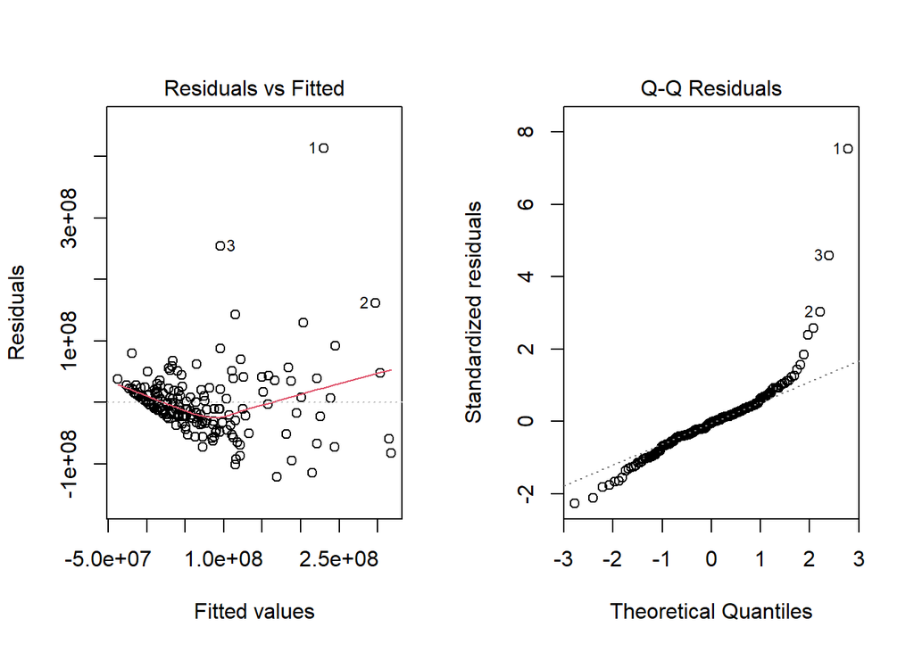

```r
# 1. Residuals vs. Fitted plot (for linearity and homoscedasticity)
# 2. Normal Q-Q plot (for normality of residuals)
par(mfrow = c(1, 2))
plot(selected_model, which = 1)
plot(selected_model, which = 2)
```

```r
# Shapiro-Wilk test for normality
shapiro.test(residuals(selected_model))
```

```
##
##  Shapiro-Wilk normality test
##
## data:  residuals(selected_model)
## W = 0.79427, p-value = 8.025e-15
```

```r
# Breusch-Pagan test for homoscedasticity (null: constant variance)
bptest(selected_model)
```

```
##
##  studentized Breusch-Pagan test
##
## data:  selected_model
## BP = 15.684, df = 6, p-value = 0.01555
```

```r
# Variance Inflation Factors (VIF) for multicollinearity (VIF > 5-10 indicates issues)
vif(selected_model)
```

```
##             Ratings              Budget             Screens              Sequel
##            1.194940            2.030247            1.671737            1.438906
##            Dislikes Aggregate.Followers
##            1.176793            1.134619
```

**Interpretation:**

- **Residuals vs. Fitted Plot:** The plot shows a distinct funnel shape, where the variance of the residuals increases as the fitted values increase. This is a clear sign of **heteroscedasticity**.
- **Normal Q-Q Plot:** The residuals deviate heavily from the theoretical line, especially at the tails, indicating they are **not normally distributed**.
- **Breusch-Pagan Test:** The p-value is small (< 0.05), so we reject the null hypothesis and confirm the presence of heteroscedasticity.
- **VIF:** All VIF values are low (<= 2), indicating that multicollinearity is not an issue in this model.

The model violates key assumptions and requires correction.

### Outlier Detection and Removal

Influential outliers can disproportionately affect model coefficients and diagnostics. We use an influence plot to identify them.

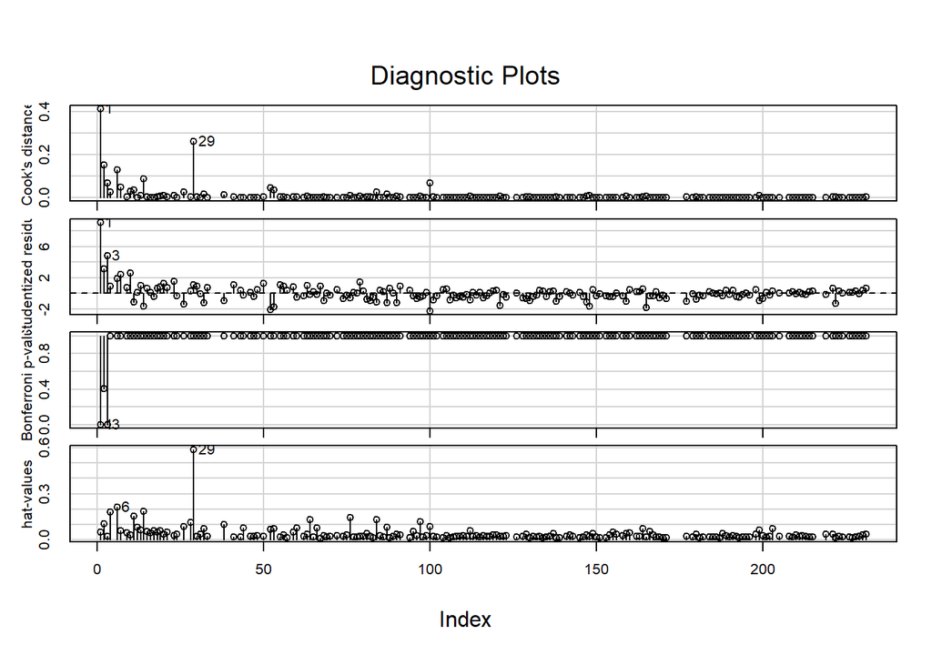

```r
# The influence plot shows Cook's distance, leverage, and studentized residuals.
influenceIndexPlot(selected_model, id = TRUE)
```

**Interpretation:**

Looking at **Cook’s distance**, the candidate points are `1` and `29`. For **studentized residuals**, the potential outliers is point 1. From the **hat values**, the potential high leverage point is `29`. By removing the points from the original dataset and constructing another summary table, we are able to determine if the points are influential points.

### Test for Outlier Removal

```r
# Remove the identified outlier rows.
outlier_rows <- c("1", "29")
train_cleaned <- train[!rownames(train) %in% outlier_rows, ]

# Refit the 6-variable model on the cleaned data.
refit_model <- lm(Gross ~ Ratings + Budget + Screens + Sequel + Dislikes + Aggregate.Followers, data = train_cleaned)
summary(refit_model)
```

```
##
## Call:
## lm(formula = Gross ~ Ratings + Budget + Screens + Sequel + Dislikes +
##     Aggregate.Followers, data = train_cleaned)
##
## Residuals:
##        Min         1Q     Median         3Q        Max
## -124992842  -23362947   -1493183   16553533  257012206
##
## Coefficients:
##                       Estimate Std. Error t value Pr(>|t|)
## (Intercept)         -1.024e+08  2.530e+07  -4.048 7.75e-05 ***
## Ratings              1.359e+07  3.761e+06   3.612 0.000396 ***
## Budget               7.541e-01  8.774e-02   8.595 4.52e-15 ***
## Screens              1.279e+04  3.041e+03   4.206 4.15e-05 ***
## Sequel               6.136e+06  4.178e+06   1.469 0.143701
## Dislikes             3.611e+02  4.322e+03   0.084 0.933504
## Aggregate.Followers  2.725e+00  7.880e-01   3.458 0.000683 ***
## ---
## Signif. codes:  0 '***' 0.001 '**' 0.01 '*' 0.05 '.' 0.1 ' ' 1
##
## Residual standard error: 46120000 on 175 degrees of freedom
## Multiple R-squared:  0.6839, Adjusted R-squared:  0.6731
## F-statistic: 63.12 on 6 and 175 DF,  p-value: < 2.2e-16
```

**Interpretation:** From our original summary table constructed with all the points in our dataset, we obtained residual standard error amount of **56120000**, R-squared value of **0.6334** and adjusted R-squared value **0.621**. This means that **62.1%** of variability in gross income is explained by our current regression model. From our new summary table, the residual standard error is **46120000** which is significantly lower than our previous residual value. This means that the errors of prediction in our model is improved. The new R-squared value is **0.6839** and the adjusted R-squared value is **0.6731**. This means that **67.31%** of the variability in gross income is explained by our current regression model which is better than the original one. Through this method, we are able to determine that the points `1` and `29` are indeed influential points and should be removed from our model.

### Re-selection After Outlier Removal

```r
# Re-run backward selection using AIC on the cleaned data.
step_aic_clean <- step(refit_model, direction = "backward", trace = 0)
summary(step_aic_clean)
```

```
##
## Call:
## lm(formula = Gross ~ Ratings + Budget + Screens + Sequel + Aggregate.Followers,
##     data = train_cleaned)
##
## Residuals:
##        Min         1Q     Median         3Q        Max
## -125263821  -23518450   -1482209   16436858  256962117
##
## Coefficients:
##                       Estimate Std. Error t value Pr(>|t|)
## (Intercept)         -1.018e+08  2.422e+07  -4.204 4.17e-05 ***
## Ratings              1.351e+07  3.650e+06   3.702 0.000286 ***
## Budget               7.546e-01  8.731e-02   8.643 3.28e-15 ***
## Screens              1.285e+04  2.938e+03   4.375 2.08e-05 ***
## Sequel               6.075e+06  4.103e+06   1.481 0.140492
## Aggregate.Followers  2.732e+00  7.805e-01   3.501 0.000588 ***
## ---
## Signif. codes:  0 '***' 0.001 '**' 0.01 '*' 0.05 '.' 0.1 ' ' 1
##
## Residual standard error: 45990000 on 176 degrees of freedom
## Multiple R-squared:  0.6839, Adjusted R-squared:  0.675
## F-statistic: 76.17 on 5 and 176 DF,  p-value: < 2.2e-16
```

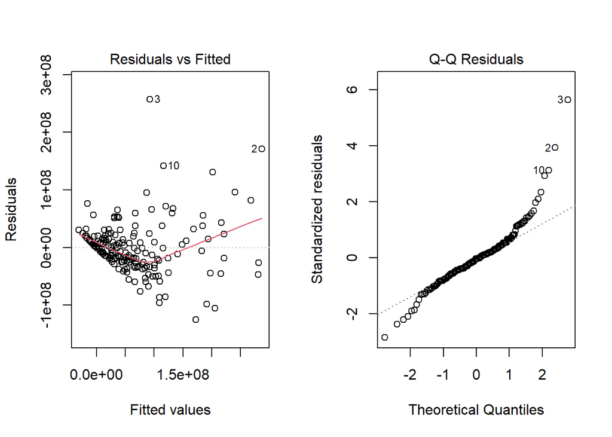

```r
# Final model post re-selection
final_model <- step_aic_clean

# Final Model Diagnostics
par(mfrow = c(1, 2))
plot(final_model, which = 1)
plot(final_model, which = 2)
```

```r
shapiro.test(residuals(final_model))
```

```
##
##  Shapiro-Wilk normality test
##
## data:  residuals(final_model)
## W = 0.9037, p-value = 1.663e-09
```

```r
bptest(final_model)
```

```
##
##  studentized Breusch-Pagan test
##
## data:  final_model
## BP = 23.981, df = 5, p-value = 0.0002189
```

```r
vif(final_model)
```

```
##             Ratings              Budget             Screens              Sequel
##            1.103999            1.989049            1.571674            1.391939
## Aggregate.Followers
##            1.128037
```

**Interpretation:**

## Predictor Transformations: Power Transform for Non-Categorical Variables

This new 5-variable model still suffers from the same assumption violations due to data skewness. We now apply transformations to correct this.

```r
trans_predictors <- powerTransform(cbind(Ratings, Budget, Screens, Sequel, Aggregate.Followers) ~ 1, data = train_cleaned, family = "bcPower")
summary(trans_predictors)
```

```
## bcPower Transformations to Multinormality
##                     Est Power Rounded Pwr Wald Lwr Bnd Wald Upr Bnd
## Ratings                1.8819        2.00       1.1207       2.6432
## Budget                 0.2137        0.21       0.1340       0.2933
## Screens                0.6341        0.63       0.5135       0.7547
## Sequel                -4.6427       -4.64      -5.4525      -3.8329
## Aggregate.Followers    0.1910        0.19       0.1265       0.2554
##
## Likelihood ratio test that transformation parameters are equal to 0
##  (all log transformations)
##                                    LRT df       pval
## LR test, lambda = (0 0 0 0 0) 494.9887  5 < 2.22e-16
##
## Likelihood ratio test that no transformations are needed
##                                    LRT df       pval
## LR test, lambda = (1 1 1 1 1) 1163.982  5 < 2.22e-16
```

**Interpretation**

This powerTransform output suggests the optimal power (lambda, λ) to make the predictor distributions more symmetric and linearize their relationships with the response.

- **Ratings**: The 95% confidence interval for the estimated power **[1.12, 2.64]** includes 2.0.
- **Budget & Aggregate.Followers**: Both variables require a strong transformation. Their estimated powers are 0.21 and 0.19, respectively. Their confidence intervals are far from 1.0 (no transformation) and 0 (log transformation). A **square-root (λ=0.5)** or **fourth-root (λ=0.25)** transformation is strongly recommended to correct their severe right-skew.
- **Screens**: The estimated power of 0.63 with a confidence interval of [0.51, 0.75] suggests that a mild transformation, weaker than a square root, is beneficial.
- **Sequel**: The function returned an estimate of -4.64. This extreme and nonsensical value indicates that powerTransform is inappropriate for this variable, as Sequel is a count/ordinal variable, not a continuous one.

## Box-Cox for Gross

We use the Box-Cox procedure to find the optimal power transformation for the response variable, `Gross`.

```r
# First, we'll transform skewed predictors. 'powerTransform' suggests sqrt for Budget and Followers.
transformed_predictors_model <- lm(Gross ~ I(Ratings**(2.0)) + sqrt(Budget) + Screens + Sequel + sqrt(Aggregate.Followers), data = train_cleaned)

# Apply Box-Cox to this model to find the optimal transformation for Gross.
boxcox_result <- boxCox(transformed_predictors_model, lambda = seq(0, 0.5, by = 0.01))
```

[figure not shown]

```r
lambda_optimal <- boxcox_result$x[which.max(boxcox_result$y)]
cat("Optimal lambda for Box-Cox transformation:", lambda_optimal, "\n")
```

```
## Optimal lambda for Box-Cox transformation: 0.3333333
```

```r
# Compute 95% confidence interval for lambda
max_log_like <- max(boxcox_result$y)
ci_threshold <- max_log_like - 0.5 * qchisq(0.95, 1)
ci_lambdas <- boxcox_result$x[boxcox_result$y >= ci_threshold]
ci_lower <- min(ci_lambdas)
ci_upper <- max(ci_lambdas)
cat("95% Confidence Interval for lambda: [", ci_lower, ",", ci_upper, "]\n")
```

```
## 95% Confidence Interval for lambda: [ 0.2828283 , 0.3838384 ]
```